# Case Study: Yawning

24 April, 2023

```r
knitr::opts_chunk$set(echo = TRUE)
library("infer")      #tools to easily compute confidence intervals
library("moderndive") #case study example
library("readxl")     #to load Excel spreadsheets
library("tidyverse")  #suite of useful data analysis packages
outlier_remover <- function(numerical_list){
  # This function will brashly remove outliers from a numerical list
  # by applying a mean plus/minus 2 standard deviations
  # range-rule-of-thumb interval
  # INPUT: a column of numerical data (missing values are okay)
  # OUTPUT: the numerical list, but with outliers replaced with "NA"

  # compute sample mean
  xbar <- mean(numerical_list,  na.rm = TRUE)

  # compute sample standard deviation
  s <- sd(numerical_list, na.rm = TRUE)

  # nullify outliers
  numerical_list[numerical_list < xbar - 2*s] <- NA
  numerical_list[numerical_list > xbar + 2*s] <- NA

  # return
  numerical_list
}

outlier_remover2 <- function(x){
  # This function will remove possible outliers in a vector
  # idea: outliers are in the extreme 10 percent of values
  # INPUT: data vector
  # OUTPUT: revised data vector without outliers

  # xbar <- mean(x, na.rm = TRUE)
  # s <- sd(x, na.rm = TRUE)
  p10 <- quantile(x, probs = 0.10, na.rm = TRUE)
  p90 <- quantile(x, probs = 0.90, na.rm = TRUE)
  n <- length(x)
  new_x <- x

  for(i in 1:n){
    if(is.na(x[i])){
      new_x[i] <- NA
    } else {
      if(x[i] >= p90){ new_x[i] <- NA }
      if(x[i] <= p10){ new_x[i] <- NA }
    }
  }

  #return
  new_x
}
```

# Case Study

After each code block, to the best of your current ability, describe what the `R` code is doing.

This material comes from Chapter 8 of *Statistical Inference via Data Science: A ModernDive into R and the Tidyverse*

- https://moderndive.com/8-confidence-intervals.html#case-study-two-prop-ci

“Let’s apply our knowledge of confidence intervals to answer the question: “Is yawning contagious?”. If you see someone else yawn, are you more likely to yawn? In an episode of the US show Mythbusters, the hosts conducted an experiment to answer this question.”

“Fifty adult participants who thought they were being considered for an appearance on the show were interviewed by a show recruiter. In the interview, the recruiter either yawned or did not. Participants then sat by themselves in a large van and were asked to wait. While in the van, the Mythbusters team watched the participants using a hidden camera to see if they yawned. The data frame containing the results of their experiment is available in the mythbusters_yawn data frame included in the moderndive package:”

```r
mythbusters_yawn
```

```
## # A tibble: 50 × 3
##     subj group   yawn
##    <int> <chr>   <chr>
##  1     1 seed    yes
##  2     2 control yes
##  3     3 seed    no
##  4     4 seed    yes
##  5     5 seed    no
##  6     6 control no
##  7     7 seed    yes
##  8     8 control no
##  9     9 control no
## 10    10 seed    no
## # ℹ 40 more rows
```

```r
mythbusters_yawn %>%
  group_by(group, yawn) %>%
  summarize(count = n())
```

```
## # A tibble: 4 × 3
## # Groups:   group [2]
##   group   yawn  count
##   <chr>   <chr> <int>
## 1 control no       12
## 2 control yes       4
## 3 seed    no       24
## 4 seed    yes      10
```

```r
mythbusters_yawn %>%
  specify(formula = yawn ~ group, success = "yes")
```

```
## Response: yawn (factor)
## Explanatory: group (factor)
## # A tibble: 50 × 2
##    yawn  group
##    <fct> <fct>
##  1 yes   seed
##  2 yes   control
##  3 no    seed
##  4 yes   seed
##  5 no    seed
##  6 no    control
##  7 yes   seed
##  8 no    control
##  9 no    control
## 10 no    seed
## # ℹ 40 more rows
```

```r
first_six_rows <- head(mythbusters_yawn)
```

```r
first_six_rows %>%
  sample_n(size = 6, replace = TRUE)
```

```
## # A tibble: 6 × 3
##    subj group   yawn
##   <int> <chr>   <chr>
## 1     6 control no
## 2     4 seed    yes
## 3     1 seed    yes
## 4     6 control no
## 5     4 seed    yes
## 6     2 control yes
```

```r
mythbusters_yawn %>%
  specify(formula = yawn ~ group, success = "yes") %>%
  generate(reps = 1000, type = "bootstrap")
```

```
## Response: yawn (factor)
## Explanatory: group (factor)
## # A tibble: 50,000 × 3
## # Groups:   replicate [1,000]
##    replicate yawn  group
##        <int> <fct> <fct>
##  1         1 no    seed
##  2         1 no    seed
##  3         1 yes   seed
##  4         1 no    control
##  5         1 no    seed
##  6         1 no    control
##  7         1 no    seed
##  8         1 yes   seed
##  9         1 no    seed
## 10         1 no    control
## # ℹ 49,990 more rows
```

```r
bootstrap_distribution_yawning <- mythbusters_yawn %>%
  specify(formula = yawn ~ group, success = "yes") %>%
  generate(reps = 1000, type = "bootstrap") %>%
  calculate(stat = "diff in props", order = c("seed", "control"))
bootstrap_distribution_yawning
```

```
## Response: yawn (factor)
## Explanatory: group (factor)
## # A tibble: 1,000 × 2
##    replicate    stat
##        <int>   <dbl>
##  1         1  0.246
##  2         2 -0.0175
##  3         3  0.117
##  4         4 -0.314
##  5         5 -0.0696
##  6         6  0.133
##  7         7  0.1
##  8         8  0.05
##  9         9  0.0476
## 10        10 -0.146
## # ℹ 990 more rows
```

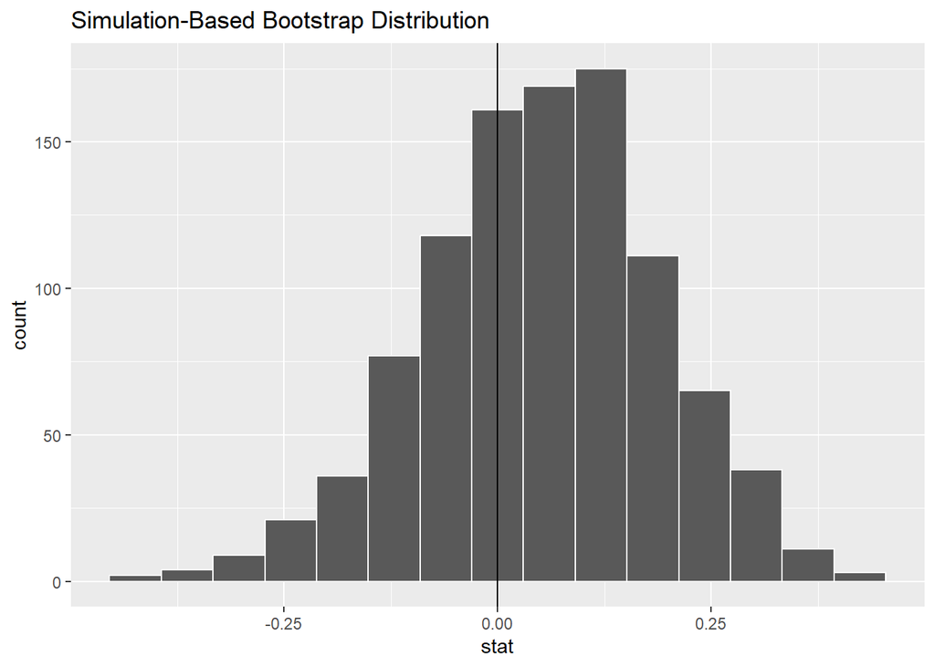

```r
visualize(bootstrap_distribution_yawning) +
  geom_vline(xintercept = 0)
```

```r
bootstrap_distribution_yawning %>%
  get_confidence_interval(type = "percentile", level = 0.95)
```

```
## # A tibble: 1 × 2
##   lower_ci upper_ci
##      <dbl>    <dbl>
## 1   -0.238    0.305
```

```r
obs_diff_in_props <- mythbusters_yawn %>%
  specify(formula = yawn ~ group, success = "yes") %>%
  # generate(reps = 1000, type = "bootstrap") %>%
  calculate(stat = "diff in props", order = c("seed", "control"))
obs_diff_in_props
```

```
## Response: yawn (factor)
## Explanatory: group (factor)
## # A tibble: 1 × 1
##     stat
##    <dbl>
## 1 0.0441
```

```r
myth_ci_se <- bootstrap_distribution_yawning %>%
  get_confidence_interval(type = "percentile", level = 0.95)
myth_ci_se
```

```
## # A tibble: 1 × 2
##   lower_ci upper_ci
##      <dbl>    <dbl>
## 1   -0.238    0.305
```

# Demographics Data

```r
# since the data is in a CSV file, we will use the read_csv() function to load the data
demo_df <- read_csv("demographics_survey_data.csv")
```

```r
# as usual, it is good to take a look at your data
# for instance, looking for numeric or categorical data
str(demo_df, give.attr = FALSE)
```

```
## spc_tbl_ [281 × 131] (S3: spec_tbl_df/tbl_df/tbl/data.frame)
##  $ enrolled            : chr [1:281] "Bio 18" "Bio 18" "Bio 18" "Bio 18" ...
##  $ home                : chr [1:281] "Central California" "Central California" "Southern California" "Central California" ...
##  $ ethnicity           : chr [1:281] "Hispanic or Latino,White or Caucausian" "Hispanic or Latino" "Hispanic or Latino" "Hispanic or Latino,White or Caucausian" ...
##  $ classStanding       : chr [1:281] "Senior" "Junior" "Sophomore" "Junior" ...
##  $ unitsCompleted      : num [1:281] 80 NA NA 104 70 NA 0 0 0 0 ...
##  $ unitsThisSemester   : num [1:281] NA 16 15 16 13 13 16 12 12 12 ...
##  $ GPA                 : num [1:281] NA NA NA NA NA NA NA NA NA NA ...
##  $ statsBefore         : chr [1:281] NA "Yes: Math 15 at UC Merced" "No" "Yes: Math 15 at UC Merced" ...
##  $ retakingWithDerek   : chr [1:281] NA "No" "No" "No" ...
##  $ learningStyle       : chr [1:281] NA "Visual" "Visual" "Visual" ...
##  $ hoursStudying       : num [1:281] NA 4 NA 2 8 50 30 5 24 NA ...
##  $ birthdayMonth       : chr [1:281] NA "December" "November" "May" ...
##  $ height              : num [1:281] NA 67 63 61 70 ...
##  $ shoeSize            : num [1:281] NA 7.5 7.5 5 11 8 9 12 10.5 9 ...
```

[output cut: 86 more lines]

## Example: How often do you brush your teeth per week?

```r
# sample statistics
demo_df %>%
  summarize(count = sum(!is.na(brushingTeeth)),
            xbar = mean(brushingTeeth, na.rm = TRUE),
            med  = median(brushingTeeth, na.rm = TRUE),
            s    = sd(brushingTeeth, na.rm = TRUE),
            missing = sum(is.na(brushingTeeth)))
```

```
## # A tibble: 1 × 5
##   count  xbar   med     s missing
##   <int> <dbl> <dbl> <dbl>   <int>
## 1   275  12.0    14  3.54       6
```

```r
# bootstrap distribution
bootstrap_distribution <- demo_df %>%
  specify(response = brushingTeeth) %>%
  generate(reps = 1337, type = "bootstrap") %>%
  calculate(stat = "mean")
# form a 95% confidence interval
bootstrap_distribution %>%
  get_confidence_interval(level = 0.95, type = "percentile")
```

```
## # A tibble: 1 × 2
##   lower_ci upper_ci
##      <dbl>    <dbl>
## 1     11.5     12.4
```

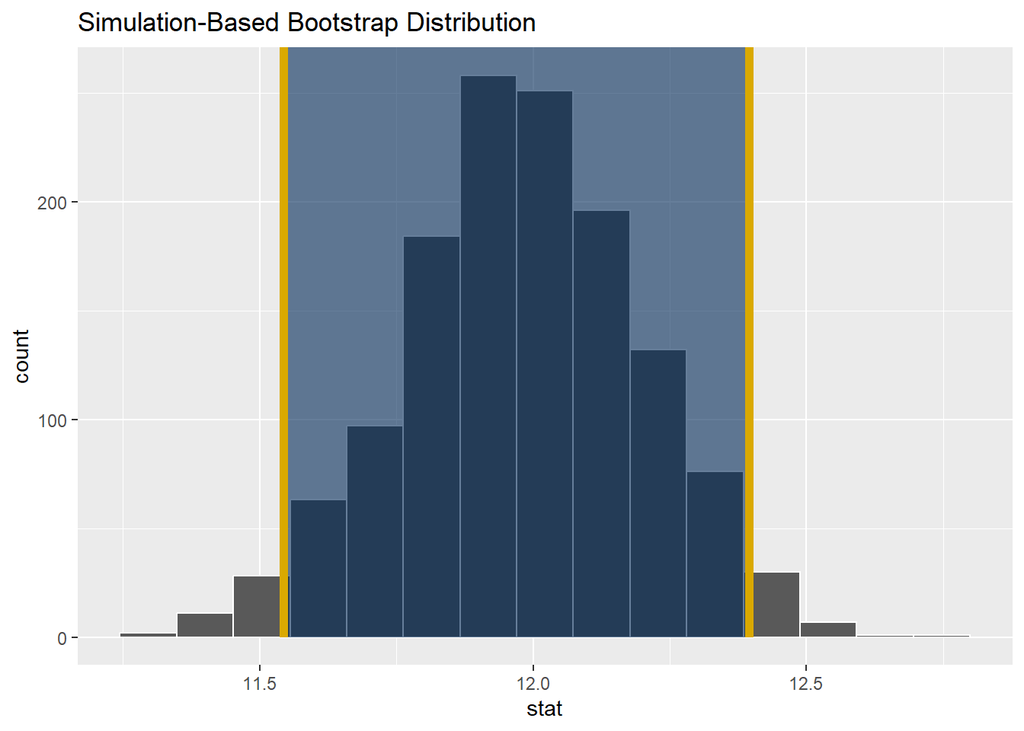

```r
# visualize the confidence interval and sampling distribution
SE_CI <- bootstrap_distribution %>%
  get_ci(level = 0.95, type = "percentile")

visualize(bootstrap_distribution) +
  shade_ci(endpoints = SE_CI, color = "#DAA900", fill = "#002856")
```

## Exercises

1. Using the `GPA` numerical data,
1. compute sample statistics
2. compute a 95% confidence interval, and describe the result in a complete sentence.
3. produce a visual of the sampling distribution and the confidence interval.
2. Using the `hoursStudying` numerical data,
1. compute sample statistics
2. compute a 95% confidence interval, and describe the result in a complete sentence.
3. produce a visual of the sampling distribution and the confidence interval.
3. Using one more column of numerical data of your choosing,
1. compute sample statistics
2. compute a 95% confidence interval, and describe the result in a complete sentence.
3. produce a visual of the sampling distribution and the confidence interval.